# assignment_sklab

Assignment sk---lab

```python
import numpy as np
import pandas as pd
import requests
import seaborn as sns
import math
```

Given csv file is the given dataset of employee.

```
<class 'pandas.core.frame.DataFrame'>
RangeIndex: 100 entries, 0 to 99
Data columns (total 5 columns):
 #   Column       Non-Null Count  Dtype
---  ------       --------------  -----
 0   Name         100 non-null    object
 1   Street       100 non-null    object
 2   Postal code  100 non-null    object
 3   City         98 non-null     object
 4   Country      100 non-null    object
dtypes: object(5)
memory usage: 4.0+ KB
None
               Name            Street Postal code       City Country
95    Umaiza French       Kaivokatu 8       00100   HELSINKI      FI
96         Una Amin     Holmankorpi 3       02210      Espoo      FI
97       Zahara Mac  ILTAPÄIVÄNKUJA 6       02210      Espoo      FI
98    Zakir Watkins     Pyynikintie 3       33200    Tampere      FI
99  Zayne Stevenson    Petsamontie 39       99800      Inari      FI
```

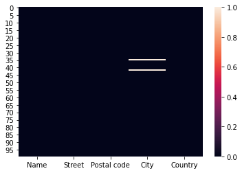

```python
employees_data = pd.read_csv('employees.csv')
print(employees_data.info())
sns.heatmap(employees_data.isnull())
print(employees_data.tail())
```

Emloyees_1.csv file is the extracted Longitude and latitude with the help of google sheet addons called geo code table calculaor. It will extract automatically required Latitude and Longitude once street address with postal code or city is given.

```python
lat_lon = pd.read_csv('employees_1.csv', sep=';')
employees_data = pd.concat([employees_data,lat_lon], axis=1)
employees_data.head(2)
```

|  | Name | Street | Postal code | City | Country | Latitude | Longitude |
| --- | --- | --- | --- | --- | --- | --- | --- |
| 0 | Abdulahi Lara | piilotie 2 | 21620 | Kaarina | FI | 60.393937 | 22.398708 |
| 1 | Abu Schultz | KARIN-HEIKINTIE 2 | 36240 | Kangasala | FI | 61.475022 | 23.944436 |

Inserting the headquater location, according to the question given. There was small typo regarding the postal code of the headquater in the assignment question. It was detected while reviewing the data via google maps. Since it is just a point, it was manually corrected while inserting the details.

```python
hq_location = {"Name":"Head quater", "Street": "Betonimienkuja 3", "Postal code": "02150",
                            "City": "Espoo", "Country": "FI", "Latitude": 60.1807142, "Longitude": 24.8318569}
hq_location_df = pd.DataFrame(hq_location,index=[0])
print(hq_location_df)
employees_data = pd.concat([hq_location_df,employees_data],ignore_index=True)
employees_data.head(2)
```

```
          Name            Street Postal code   City Country   Latitude  \
0  Head quater  Betonimienkuja 3       02150  Espoo      FI  60.180714

   Longitude
0  24.831857
```

|  | Name | Street | Postal code | City | Country | Latitude | Longitude |
| --- | --- | --- | --- | --- | --- | --- | --- |
| 0 | Head quater | Betonimienkuja 3 | 02150 | Espoo | FI | 60.180714 | 24.831857 |
| 1 | Abdulahi Lara | piilotie 2 | 21620 | Kaarina | FI | 60.393937 | 22.398708 |

Below distance calculation is custom calculation done to extract the shortest distance between employees address and headquaters.

```python
# Distance calculation
def coordinate_dislat(x1):
    val = (x1-math.radians(60.180714))
    return val
def coordinate_dislon(y1):
    val= (y1-math.radians(24.8318569))
    return val
# calculating the radian value
employees_data['radx']= employees_data["Latitude"].apply(math.radians)
employees_data['rady']= employees_data["Longitude"].apply(math.radians)
# performing difference in randian value with the headquater radians
employees_data['Dlat'] = employees_data['radx'].apply(coordinate_dislat)
employees_data['Dlon'] = employees_data['rady'].apply(coordinate_dislon)

## Haversine formula for the actual distance calculation in map
# a = sin²(ΔlatDifference/2) + cos(lat1).cos(lt2).sin²(ΔlonDifference/2)
# shortest_distance = 2 * sina(sqrt(a)) * radius of earth

# Adusting dataframe environment to perform above formula and to find shortest distance to the headquater

employees_data["Sin_sq_dlat"]=employees_data["Dlat"].apply(lambda x: math.sin(x/2)**2)
employees_data["Sin_sq_dlon"]=employees_data["Dlon"].apply(lambda x: math.sin(x/2)**2)
employees_data["cos_rad_headquater"]=employees_data["Dlon"].apply(lambda x: math.cos(math.radians(60.180714)))
employees_data['cos_radx'] = employees_data['radx'].apply(lambda x: math.cos(x))
radius_of_earth = 6371
# finding the value of a
employees_data["value_of_a"] = employees_data['Sin_sq_dlat'] + employees_data['cos_rad_headquater'] * employees_data['cos_radx'] * employees_data['Sin_sq_dlon']
# finding the value of distance from headquater
employees_data['distance_to_headquater_km'] = employees_data['value_of_a'].apply(lambda x: 2* radius_of_earth * math.asin(math.sqrt(x)))
#rounding the distance value
employees_data['distance_to_headquater_km'] = employees_data['distance_to_headquater_km'].apply(round)
# Poping out unnecessary column generated during the calculation
del_column = ['radx', 'rady', 'Dlat', 'Dlon', 'Sin_sq_dlat', 'Sin_sq_dlon', 'cos_rad_headquater', 'cos_radx', 'value_of_a']
employees_data = employees_data.drop(del_column,axis=1)
print(employees_data.head(2))
```

```
            Name            Street Postal code     City Country   Latitude  \
0    Head quater  Betonimienkuja 3       02150    Espoo      FI  60.180714
1  Abdulahi Lara        piilotie 2       21620  Kaarina      FI  60.393937

   Longitude  distance_to_headquater_km
0  24.831857                          0
1  22.398708                        136
```

```python
employees_data.head(2)
```

|  | Name | Street | Postal code | City | Country | Latitude | Longitude | distance_to_headquater_km |
| --- | --- | --- | --- | --- | --- | --- | --- | --- |
| 0 | Head quater | Betonimienkuja 3 | 02150 | Espoo | FI | 60.180714 | 24.831857 | 0 |
| 1 | Abdulahi Lara | piilotie 2 | 21620 | Kaarina | FI | 60.393937 | 22.398708 | 136 |

```python
print(employees_data.describe())
# shows the value of shortest distance 1889 km which inside of Finland is quite not true, let's check the actual rows
print(employees_data[employees_data.distance_to_headquater_km==1889])
# This address is somewhere in UK .
# We are analysing the data in Finland so let's pop it out too.
employees_data = employees_data.drop(64,axis=0)
print(employees_data.describe())
employees_data[62:66]
```

```
         Latitude   Longitude  distance_to_headquater_km
count  101.000000  101.000000                 101.000000
mean    61.371042   24.391964                 181.811881
std      1.870679    3.256319                 254.555759
min     53.295706   -3.835711                   0.000000
25%     60.229054   23.757206                  10.000000
50%     60.743728   24.843902                 104.000000
75%     62.252654   25.130091                 266.000000
max     68.662606   29.763114                1889.000000
         Name        Street Postal code     City Country   Latitude  \
64  Leroy Lee  STATION ROAD    LL31 9FA  DEGANWY      FI  53.295706

    Longitude  distance_to_headquater_km
64  -3.835711                       1889
         Latitude   Longitude  distance_to_headquater_km
count  100.000000  100.000000                 100.000000
mean    61.451796   24.674241                 164.740000
std      1.693961    1.606778                 188.995945
min     59.978607   21.229202                   0.000000
25%     60.231450   23.812985                   9.750000
50%     60.768392   24.846387                 102.000000
75%     62.263828   25.145956                 266.000000
max     68.662606   29.763114                 952.000000
```

|  | Name | Street | Postal code | City | Country | Latitude | Longitude | distance_to_headquater_km |
| --- | --- | --- | --- | --- | --- | --- | --- | --- |
| 62 | Lacie-Mae Smart | TÄHKÄTIE 3 | 00390 | Helsinki | FI | 60.241372 | 24.843902 | 7 |
| 63 | Lennon Blake | SUNDSGATAN 13 | 65200 | Vaasa | FI | 63.107424 | 21.586728 | 368 |
| 65 | Liya Thorpe | ALEKSIS KIVENKATU 48 | 00510 | Helsinki | FI | 60.191444 | 24.946948 | 6 |
| 66 | Luis Mcdermott | KUNINKAANTAMMENKIERTO 12 | 00430 | Helsinki | FI | 60.260740 | 24.886982 | 9 |

```python
employees_data[employees_data.distance_to_headquater_km==952]
```

|  | Name | Street | Postal code | City | Country | Latitude | Longitude | distance_to_headquater_km |
| --- | --- | --- | --- | --- | --- | --- | --- | --- |
| 100 | Zayne Stevenson | Petsamontie 39 | 99800 | Inari | FI | 68.662606 | 27.566858 | 952 |

After the deleting the unnecessary row, we have now maximum shortest distance value is 952 kilometer from the headquater. This seems to be reasonable. Still cross-checking with google maps we found that inari is the small town in northernmost part of the finland. The value obtained is convincing and reasonable.

We have now the distance of employee's living to the headquaters. This makes us to answer 2 out of 3 question regarding the assignment. To answer the Third question, we are taking the data from the statistics finland. The other part is assumption, which is taken as following:

```
1. To find the wealthiest region, we will directly relate the attribute related to the yearly income of individual according to the  postal address. i.e. in summary where the income of individual is higher, wealthiest the region.
```

```python
# downloading the data from the server
url = "https://geo.stat.fi/geoserver/wfs?service=WFS&version=2.0.0&request=GetFeature&typeName=postialue:pno_tilasto&outputFormat=csv"
data = pd.read_csv(url)
print(data.head(2))

# Out of lots of column, we are at this moment just selecting the average yearly income and postal code from the downloded data.
data_selected = data[["postinumeroalue", "hr_ktu"]]
# Renaming the column to have the better understanding of data
data_selected = data_selected.rename(columns={'postinumeroalue':'Postal code', 'hr_ktu': 'Yearly_avg_income'})
print(data_selected.head(2))
```

```
              FID                                               geom  \
0  pno_tilasto.24  MULTIPOLYGON (((381041.8568000002 6672713.2391...
1  pno_tilasto.25  MULTIPOLYGON (((382843.9606999997 6676971.9386...

   postinumeroalue                    nimi                   namn  euref_x  \
0              340   Kuusisaari-Lehtisaari             Granö-Lövö   380834
1              350  Munkkivuori-Niemenmäki  Munkshöjden-Näshöjden   381714

   euref_y  pinta_ala  vuosi  kunta  ...  tp_t_koti  tp_u_kans  tp_x_tunt  \
0  6673255    1008214   2021     91  ...          0          6          0
1  6676414    2211028   2021     91  ...          0          0          0

   pt_vakiy  pt_tyoll  pt_tyott  pt_0_14  pt_opisk  pt_elakel  pt_muut
0      1767       807        46      266       141        404      103
1      9280      4785       374     1275       745       1802      299

[2 rows x 113 columns]
   Postal code  Yearly_avg_income
0          340              63919
1          350              29152
```

```python
print(len(employees_data['Postal code'].unique()))
print(employees_data.info())
```

```
99
<class 'pandas.core.frame.DataFrame'>
Int64Index: 100 entries, 0 to 100
Data columns (total 8 columns):
 #   Column                     Non-Null Count  Dtype
---  ------                     --------------  -----
 0   Name                       100 non-null    object
 1   Street                     100 non-null    object
 2   Postal code                100 non-null    object
 3   City                       98 non-null     object
 4   Country                    100 non-null    object
 5   Latitude                   100 non-null    float64
 6   Longitude                  100 non-null    float64
 7   distance_to_headquater_km  100 non-null    int64
dtypes: float64(2), int64(1), object(5)
memory usage: 7.0+ KB
None
```

To merge the two dataframe, we need to figure out the suitability (i.e. inner, outer, left, right). Our data out of 100, 99 is the unique Postal code. This means there is the repetition of Postal code. This means, two employee living in same region working at the same office. This is common to happen. Therefore, we are taking the left join, to avoide the data loss. But before that, datatypes of Postal code must be change to avoide the error while performing the join.

```python
# changing the data types
employees_data['Postal code']=employees_data['Postal code'].apply(int)
# performing left join
employees_data = employees_data.merge(data_selected, on = 'Postal code', how = 'left')
print(employees_data.info())
```

```
<class 'pandas.core.frame.DataFrame'>
Int64Index: 100 entries, 0 to 99
Data columns (total 9 columns):
 #   Column                     Non-Null Count  Dtype
---  ------                     --------------  -----
 0   Name                       100 non-null    object
 1   Street                     100 non-null    object
 2   Postal code                100 non-null    int64
 3   City                       98 non-null     object
 4   Country                    100 non-null    object
 5   Latitude                   100 non-null    float64
 6   Longitude                  100 non-null    float64
 7   distance_to_headquater_km  100 non-null    int64
 8   Yearly_avg_income          99 non-null     float64
dtypes: float64(3), int64(2), object(4)
memory usage: 7.8+ KB
None
```

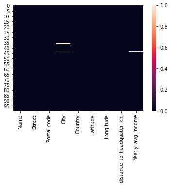

```python
sns.heatmap(employees_data.isnull())
```

```
40    20600.0
41    23310.0
42    27130.0
43    61933.0
44        NaN
Name: Yearly_avg_income, dtype: float64
Name                         Humphrey Schneider
Street                           FRISKINPOLKU 8
Postal code                               26360
City                                      Turku
Country                                      FI
Latitude                                60.4878
Longitude                               22.2663
distance_to_headquater_km                   145
Yearly_avg_income                           NaN
Name: 44, dtype: object
                  Name          Street  Postal code   City Country   Latitude  \
44  Humphrey Schneider  FRISKINPOLKU 8        26360  Turku      FI  60.487821

    Longitude  distance_to_headquater_km  Yearly_avg_income
44  22.266304                        145                NaN
Empty DataFrame
Columns: [Postal code, Yearly_avg_income]
Index: []
```

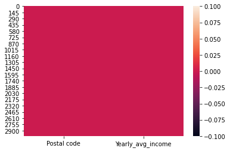

```python
# above heatmap shows somewhere in the index between 40 to 45 shows the null value, let's fix this issue
print(employees_data.Yearly_avg_income[40:45])
# it seems like index 44 have not the yearly_avg_income
# further let's see what we can find in that index
print(employees_data.iloc[44,:])
# checking if there is null value in data_selected data frame
sns.heatmap(data_selected.isnull())
#It seems to have all the postal code and values
#further checking the information of null value index
print(employees_data[employees_data['Postal code']==26360])
print(data_selected[data_selected['Postal code']==26360])
# While cross checking the google maps and data_selected data frame, it is found that there is a typo. It seems,
# instead of 20360 there is 26360
# Let's correct this typo and fill the nan value with correct information
# on reviewing avg yearly income of the postal code region 20360 is 21333.
employees_data['Postal code'][44]=20360
employees_data['Yearly_avg_income'][44]=21333
employees_data['City'][43] = 'Helsinki'
employees_data['City'][36] = 'Oulu'
```

```
Name                         Humphrey Schneider
Street                           FRISKINPOLKU 8
Postal code                               20360
City                                      Turku
Country                                      FI
Latitude                                60.4878
Longitude                               22.2663
distance_to_headquater_km                   145
Yearly_avg_income                         21333
Name: 44, dtype: object
```

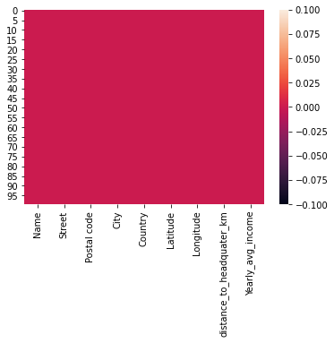

```python
# checking the dataframe after adjusting
print(employees_data.iloc[44,])
sns.heatmap(employees_data.isnull())
```

```python
# let's review our final dataframe to answer all three question asked on the assignment
employees_data.head()
```

|  | Name | Street | Postal code | City | Country | Latitude | Longitude | distance_to_headquater_km | Yearly_avg_income |
| --- | --- | --- | --- | --- | --- | --- | --- | --- | --- |
| 0 | Head quater | Betonimienkuja 3 | 2150 | Espoo | FI | 60.180714 | 24.831857 | 0 | 13650.0 |
| 1 | Abdulahi Lara | piilotie 2 | 21620 | Kaarina | FI | 60.393937 | 22.398708 | 136 | 40423.0 |
| 2 | Abu Schultz | KARIN-HEIKINTIE 2 | 36240 | Kangasala | FI | 61.475022 | 23.944436 | 152 | 26853.0 |
| 3 | Aishah Plummer | Jungarvägen 27 B | 66850 | Uusikaarlepyy | FI | 63.521760 | 22.530356 | 391 | 27588.0 |
| 4 | Aleksandra Riley | NAHKATEHTAANKUJA 2 | 4300 | Tuusula | FI | 60.402046 | 25.017265 | 27 | 30340.0 |

#### Who lives closest to the company Head-quater

```python
closest_to_headquater = employees_data.sort_values('distance_to_headquater_km').iloc[1,:]
print('----------------------------------')
print(f'The employee who lives closest to the headquater is {closest_to_headquater.Name}')
print('----------------------------------')
print(closest_to_headquater)
```

```
----------------------------------
The employee who lives closest to the headquater is Carol Guzman
----------------------------------
Name                              Carol Guzman
Street                       Lehtisaarentie 8a
Postal code                                340
City                                  Helsinki
Country                                     FI
Latitude                               60.1786
Longitude                              24.8536
distance_to_headquater_km                    1
Yearly_avg_income                        63919
Name: 21, dtype: object
```

#### How many people live within 10km of the office

```python
#Adjusting new column with status of employee to determine the employee location and headquater location.
employees_data['Status'] = employees_data.distance_to_headquater_km==0
employees_data.Status='Employee'
employees_data.Status[0] = 'Headquater'
within_ten_km = employees_data[employees_data.distance_to_headquater_km <= 10]
print('---------------------------------')
print(f"Number of people living within 10 km from the office is {len(within_ten_km)-1}")
# Within_ten_km dataframe includes the headquater itself so to find number of people we have to substract 1 from the length.
print('---------------------------------')
```

```
---------------------------------
Number of people living within 10 km from the office is 25
---------------------------------
```

#### List three employees living in the wealthiest regions

```python
# sorting wealthiest region among the employees address
wealthiest_region = employees_data.sort_values('Yearly_avg_income', ascending=False)
# Thus three employees among all the employees living in wealthiest region is:
employees_in_welthiest_region = wealthiest_region.iloc[:3]
#Adusting the new columns for the visualization

print('----------------------------------------')
print(f'The name of three employee living in welthiest region are {employees_in_welthiest_region.Name[21]} , {employees_in_welthiest_region.Name[43]}, and {employees_in_welthiest_region.Name[77]}.')
print("----------------------------------------")
print('There information in below:')
print(employees_in_welthiest_region)
```

```
----------------------------------------
The name of three employee living in welthiest region are Carol Guzman , Herbert Palmer, and Preston King.
----------------------------------------
There information in below:
              Name               Street  Postal code      City Country  \
21    Carol Guzman    Lehtisaarentie 8a          340  Helsinki      FI
43  Herbert Palmer  KORKEAVUORENKATU 31          130  Helsinki      FI
77    Preston King  Kruununvuorenkatu 5          160  Helsinki      FI

     Latitude  Longitude  distance_to_headquater_km  Yearly_avg_income  \
21  60.178612  24.853646                          1            63919.0
43  60.164607  24.946212                          7            61933.0
77  60.166647  24.969700                          8            44623.0

      Status
21  Employee
43  Employee
77  Employee
```

#### Visualization for the question answer

```python
from matplotlib import pyplot as plt
import plotly.graph_objects as go
import chart_studio.plotly as py
import cufflinks as cf
from plotly.offline import iplot, init_notebook_mode
import plotly.express as px

%matplotlib inline
init_notebook_mode(connected=True)
cf.go_offline(connected=True)

cf.set_config_file(theme="pearl")
```

```python
#Developing function for plotting map.
def plot_map(dataframe,color,title):
    fig = px.scatter_geo(dataframe, lat='Latitude', lon = 'Longitude',
                     color = color, size= 'Yearly_avg_income',
                     hover_data =['distance_to_headquater_km'],
                     hover_name ='Name', scope='europe', basemap_visible=True, width=800,height=800,
                     opacity=0.5,projection='mercator',center = {'lat':60, 'lon':24},
                    title=title)
    fig.show()
```

#### Dataset Details in the Figure.

```python
plot_map(employees_data, 'Status', 'Distance and Yearly avg information of Employee')
```

[interactive chart not shown]

#### Nearest Employee from headquater

```python
df = employees_data.sort_values('distance_to_headquater_km').iloc[:2,:]
plot_map(df,'Name','Neareast employee to the Headquater')
```

[interactive chart not shown]

#### Employee within 10 km Radius

```python
plot_map(within_ten_km,'Name','Employee within 10 km radius')
```

[interactive chart not shown]

#### Wealthiest region employees among all the employees

```python
plot_map(employees_in_welthiest_region,'Name','Wealthiest Region Employee')
```

[interactive chart not shown]